# Subplots and Altair

```python
import pandas as pd
import altair as alt
from vega_datasets import data
```

```python
df = data.iris()
df.info()
```

```
<class 'pandas.core.frame.DataFrame'>
RangeIndex: 150 entries, 0 to 149
Data columns (total 5 columns):
 #   Column       Non-Null Count  Dtype
---  ------       --------------  -----
 0   sepalLength  150 non-null    float64
 1   sepalWidth   150 non-null    float64
 2   petalLength  150 non-null    float64
 3   petalWidth   150 non-null    float64
 4   species      150 non-null    object
dtypes: float64(4), object(1)
memory usage: 6.0+ KB
```

# Columns and Rows

Just as we can distinguish categorical variables by setting a `color` parameter, we can break a plot into subplots by category by using a `column` or `row` category.

The iris dataset is made up of three species. Here we'll plot each species singly as subplots in a single plot, first by column, and then by row.

## Columnwise

```python
alt.Chart(df).mark_circle().encode(
    x='petalLength',
    y='petalWidth',
    column='species').properties(
    width=200,
    height=200)
```

[interactive chart not shown]

## Row-wise

```python
alt.Chart(df).mark_circle().encode(
    x='petalLength',
    y='petalWidth',
    row='species').properties(
    width=200,
    height=200)
```

[interactive chart not shown]

# Superimposing Charts

## A Histogram

We can superimpose charts on one another. Here, we create a histogram.

```python
h = alt.Chart(df).mark_bar().encode(
    x=alt.X('petalLength', bin=alt.Bin(maxbins=20)),
    y='count()')
h
```

[interactive chart not shown]

## Boxplot

And here we create a boxplot of the same data:

```python
b = alt.Chart(df).mark_boxplot().encode(
    x="petalLength:Q")
b
```

[interactive chart not shown]

## Combining the histogram and the boxplot

```python
h + b
```

[interactive chart not shown]

We can easily change the fill colours to make the plots more distinguishable.

```python
h = alt.Chart(df).mark_bar(color='lightblue').encode(
    x=alt.X('petalLength', bin=alt.Bin(maxbins=20)),
    y='count()')

b = alt.Chart(df).mark_boxplot(color='crimson').encode(
    x="petalLength:Q")

h + b
```

[interactive chart not shown]

## Combining the Plots

| Code | Result | Alternative Code |
| --- | --- | --- |
| `a & b` | Combine plots row-wise. | `alt.vconcat(a,b)` |
| `a \| b` | Combine plots column-wise. | `alt.hconcat(a,b)` |
| `a + b` | Overlay plots. | `alt.layer(a,b)` |

# Repeat Plots

Repeat plots are the equivalent of the `pandas` native `.scatter_matrix()` method.

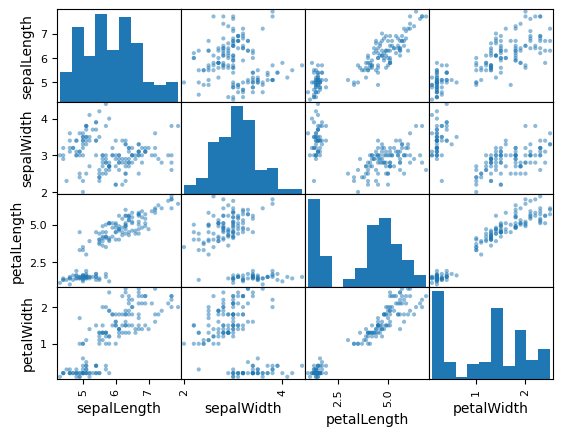

```python
pd.plotting.scatter_matrix(df);
```

To create an `altair` repeat plot, we need a list of rows and columns that we want repeated. These will be the numerical columns in the iris dataset.

```python
numerical_columns = df.columns[:-1].to_list()
numerical_columns
```

```
['sepalLength', 'sepalWidth', 'petalLength', 'petalWidth']
```

Note that `numerical_columns` is a list. Using a `pd.series` or `np.array` will just throw an error.

```python
tooltip = df.columns.to_list()
alt.Chart(df).mark_circle().encode(
    x=alt.X(alt.repeat('row'), type='quantitative'),
    y=alt.Y(alt.repeat('column'), type='quantitative'),
    color='species',
    tooltip=tooltip).properties(
    width=150,
    height=150).repeat(
    row=numerical_columns,
    column=numerical_columns)
```

[interactive chart not shown]

More colorful, more interactive, more customizable. Winner all the way.

# The Original Video

[video not shown]